# Assignment 1: Data Preprocessing and EDA for E‑Commerce Orders

This notebook is your working template for **Assignment 1**.

You will:

- Load **four tables** (`orders`, `order_items`, `order_shipping`, `payments`).
- Join them into a single order-level dataset.
- Clean and transform the data.
- Perform basic EDA and visualization.

Work **top-to-bottom**. Complete each sub-part in the order they appear before proceeding.

## Submitted by

Group number on Canvas:

| Student ID (AxxxxxxxZ) | NUSNet ID (exxxxxxx) | Name (as it appears on Canvas) |
| --- | --- | --- |
| A0328957J | e1553284@u.nus.edu | Liang Jing |
| A0328035J | e1546790@u.nus.edu | Shen Yitong |
| A0328839L | e1553166@u.nus.edu | Tay Dinghan |
| A0329062H | e1553389@u.nus.edu | Luo Shangyi |

## Setup

Run the cell below to import the required Python packages.

```python
from google.colab import drive
drive.mount('/content/drive')
```

```python
import numpy as np
import pandas as pd
import matplotlib.pyplot as plt
import sklearn
import seaborn as sns

plt.style.use('seaborn-v0_8')
```

## Part 1: Data Preprocessing (10 marks)

### 1.1 Data Loading & Joining (4 marks)

We first load each table, inspect it, and then join them into a single DataFrame.

#### Load the CSV files

**Task:**

- Dowload the four CSV files from canvas and upload them under the 'files' tab for this colab instance
- Load the four CSV files using `pd.read_csv()` into:
  - `df_orders`
  - `df_order_items`
  - `df_shipping`
  - `df_payments`

Update the filenames/paths if necessary.

```python
# ANSWER: load the CSV files
df_orders = pd.read_csv('/content/drive/MyDrive/orders.csv')
df_order_items = pd.read_csv('/content/drive/MyDrive/order_items.csv')
df_shipping = pd.read_csv('/content/drive/MyDrive/order_shipping.csv')
df_payments = pd.read_csv('/content/drive/MyDrive/payments.csv')
```

#### Inspect each table

**Task:**

- For **each** DataFrame, display:
  - `head()` (first 5 rows)
  - `shape` (rows, columns)

This helps you understand the raw structure before joining.

```python
# ANSWER: inspect the DataFrames
# def_orsers
display(df_orders.head(5))
display(df_orders.shape)

# df_order_items
display(df_order_items.head(5))
display(df_order_items.shape)

# df_shipping
display(df_shipping.head(5))
display(df_shipping.shape)

# df_payments
display(df_payments.head(5))
display(df_payments.shape)
```

|  | order_id | order_status | order_purchase_hour | order_purchase_dayofweek | order_purchase_month | order_total_value |
| --- | --- | --- | --- | --- | --- | --- |
| 0 | sdv-id-whzjUX | shipped | 10 | 4 | 4 | 744.312535 |
| 1 | sdv-id-gqShVM | delivered | 19 | 2 | 4 | 1030.521912 |
| 2 | sdv-id-vtaqcY | delivered | 18 | 4 | 8 | 28.472994 |
| 3 | sdv-id-xkqwdo | invoiced | 23 | 1 | 8 | 143.914263 |
| 4 | sdv-id-sGyHvQ | delivered | 19 | 0 | 2 | 16.944537 |

```
(100000, 6)
```

|  | order_id | num_items | num_unique_products | num_unique_sellers | total_item_price | avg_item_price | total_freight_value | top_product_category |
| --- | --- | --- | --- | --- | --- | --- | --- | --- |
| 0 | sdv-id-whzjUX | 1 | 1 | 1 | 352.420029 | 369.966521 | 68.790159 | construction_tools_construction |
| 1 | sdv-id-gqShVM | 1 | 1 | 1 | 1580.187928 | 1089.284136 | 84.603289 | auto |
| 2 | sdv-id-vtaqcY | 1 | 1 | 1 | 45.969263 | 36.969754 | 24.022637 | furniture_decor |
| 3 | sdv-id-xkqwdo | 1 | 1 | 1 | 146.023435 | 126.755360 | 16.945349 | consoles_games |
| 4 | sdv-id-sGyHvQ | 1 | 1 | 1 | 30.525812 | 22.797409 | 17.785846 | air_conditioning |

```
(100000, 8)
```

|  | order_id | customer_state |
| --- | --- | --- |
| 0 | sdv-id-whzjUX | Massachusetts |
| 1 | sdv-id-gqShVM | Ohio |
| 2 | sdv-id-vtaqcY | Wisconsin |
| 3 | sdv-id-xkqwdo | Michigan |
| 4 | sdv-id-sGyHvQ | Nevada |

```
(100000, 2)
```

|  | order_id | payment_type |
| --- | --- | --- |
| 0 | sdv-id-whzjUX | voucher |
| 1 | sdv-id-gqShVM | voucher |
| 2 | sdv-id-vtaqcY | voucher |
| 3 | sdv-id-xkqwdo | credit_card |
| 4 | sdv-id-sGyHvQ | credit_card |

```
(100000, 2)
```

#### Join the tables on `order_id` to create a single order-level DataFrame

**Task:**

- Perform **inner joins** on `order_id` so that only orders present in **all** tables remain.
- Join order tables in this order:
  1. `df_orders` with `df_order_items`
  2. result with `df_shipping`
  3. result with `df_payments`
- Store the final DataFrame as `df_orders_full`.
- Display `head()` and `shape` for `df_orders_full`.

```python
# ANSWER: join the tables
result = pd.merge(df_orders, df_order_items, on = 'order_id', how = 'inner')
result = pd.merge(result, df_shipping, on = 'order_id', how = 'inner')
result = pd.merge(result, df_payments, on = 'order_id', how = 'inner')
df_orders_full = result
```

```python
# Display
display(df_orders_full.head())
display(df_orders_full.shape)
```

|  | order_id | order_status | order_purchase_hour | order_purchase_dayofweek | order_purchase_month | order_total_value | num_items | num_unique_products | num_unique_sellers | total_item_price | avg_item_price | total_freight_value | top_product_category | customer_state | payment_type |
| --- | --- | --- | --- | --- | --- | --- | --- | --- | --- | --- | --- | --- | --- | --- | --- |
| 0 | sdv-id-whzjUX | shipped | 10 | 4 | 4 | 744.312535 | 1 | 1 | 1 | 352.420029 | 369.966521 | 68.790159 | construction_tools_construction | Massachusetts | voucher |
| 1 | sdv-id-gqShVM | delivered | 19 | 2 | 4 | 1030.521912 | 1 | 1 | 1 | 1580.187928 | 1089.284136 | 84.603289 | auto | Ohio | voucher |
| 2 | sdv-id-vtaqcY | delivered | 18 | 4 | 8 | 28.472994 | 1 | 1 | 1 | 45.969263 | 36.969754 | 24.022637 | furniture_decor | Wisconsin | voucher |
| 3 | sdv-id-xkqwdo | invoiced | 23 | 1 | 8 | 143.914263 | 1 | 1 | 1 | 146.023435 | 126.755360 | 16.945349 | consoles_games | Michigan | credit_card |
| 4 | sdv-id-sGyHvQ | delivered | 19 | 0 | 2 | 16.944537 | 1 | 1 | 1 | 30.525812 | 22.797409 | 17.785846 | air_conditioning | Nevada | credit_card |

```
(100000, 15)
```

### 1.2 Data Cleaning (3 marks)

We now clean `df_orders_full` so it is ready for analysis.

#### Handle missing values

**Task:**

- For **numerical** columns: replace missing values with the **median** of that column.
- For **categorical** columns: replace missing values with the **mode** (most frequent value).
- Drop any rows where `order_id` or `payment_type` is missing (if any remain)

Work directly on `df_orders_full`.

```python
# ANSWER: Handle missing values

# For numerical columns: replace missing values with the median of that column.
values = {
    'order_purchase_hour': df_orders_full['order_purchase_hour'].median(),
    'order_purchase_dayofweek': df_orders_full['order_purchase_dayofweek'].median(),
    'order_purchase_month': df_orders_full['order_purchase_month'].median(),
    'order_total_value': df_orders_full['order_total_value'].median(),
    'num_items': df_orders_full['num_items'].median(),
    'num_unique_products': df_orders_full['num_unique_products'].median(),
    'num_unique_sellers': df_orders_full['num_unique_sellers'].median(),
    'total_item_price': df_orders_full['total_item_price'].median(),
    'avg_item_price': df_orders_full['avg_item_price'].median(),
    'total_freight_value': df_orders_full['total_freight_value'].median()
}
df_orders_full.fillna(value=values, inplace=True)

# For categorical columns: replace missing values with the mode (most frequent value).
values = {
    'order_status': df_orders_full['order_status'].mode()[0],
    'top_product_category': df_orders_full['top_product_category'].mode()[0],
    'customer_state': df_orders_full['customer_state'].mode()[0],
    'payment_type': df_orders_full['payment_type'].mode()[0]
}
df_orders_full.fillna(value=values, inplace=True)

# Drop any rows where order_id or payment_type is missing (if any remain)
df_orders_full.dropna(subset=['order_id', 'payment_type'], inplace=True)
```

```python
# show the table
df_orders_full.head(100)
```

|  | order_id | order_status | order_purchase_hour | order_purchase_dayofweek | order_purchase_month | order_total_value | num_items | num_unique_products | num_unique_sellers | total_item_price | avg_item_price | total_freight_value | top_product_category | customer_state | payment_type |
| --- | --- | --- | --- | --- | --- | --- | --- | --- | --- | --- | --- | --- | --- | --- | --- |
| 0 | sdv-id-whzjUX | shipped | 10 | 4 | 4 | 744.312535 | 1 | 1 | 1 | 352.420029 | 369.966521 | 68.790159 | construction_tools_construction | Massachusetts | voucher |
| 1 | sdv-id-gqShVM | delivered | 19 | 2 | 4 | 1030.521912 | 1 | 1 | 1 | 1580.187928 | 1089.284136 | 84.603289 | auto | Ohio | voucher |
| 2 | sdv-id-vtaqcY | delivered | 18 | 4 | 8 | 28.472994 | 1 | 1 | 1 | 45.969263 | 36.969754 | 24.022637 | furniture_decor | Wisconsin | voucher |
| 3 | sdv-id-xkqwdo | invoiced | 23 | 1 | 8 | 143.914263 | 1 | 1 | 1 | 146.023435 | 126.755360 | 16.945349 | consoles_games | Michigan | credit_card |
| 4 | sdv-id-sGyHvQ | delivered | 19 | 0 | 2 | 16.944537 | 1 | 1 | 1 | 30.525812 | 22.797409 | 17.785846 | air_conditioning | Nevada | credit_card |
| ... | ... | ... | ... | ... | ... | ... | ... | ... | ... | ... | ... | ... | ... | ... | ... |
| 95 | sdv-id-KWHEuq | delivered | 11 | 6 | 6 | 50.941375 | 1 | 1 | 1 | 26.200144 | 26.240663 | 2.451625 | health_beauty | Colorado | credit_card |
| 96 | sdv-id-ssBsOV | delivered | 9 | 6 | 3 | 453.521760 | 1 | 1 | 1 | 294.219915 | 339.356874 | 47.605263 | garden_tools | Louisiana | credit_card |
| 97 | sdv-id-ZSPmUp | delivered | 17 | 4 | 10 | 229.915743 | 1 | 1 | 1 | 346.118532 | 281.149880 | 20.021800 | watches_gifts | New York | credit_card |
| 98 | sdv-id-qGWHIg | delivered | 16 | 0 | 12 | 82.796880 | 1 | 1 | 1 | 66.267032 | 54.715852 | 15.819753 | toys | Idaho | credit_card |
| 99 | sdv-id-ORtYxC | delivered | 17 | 1 | 8 | 51.572482 | 1 | 1 | 1 | 27.399821 | 32.927995 | 31.268998 | audio | New Jersey | voucher |

100 rows × 15 columns

#### Remove clearly invalid numeric records

**Task:**

- Remove rows where:
  - `num_items` ≤ 0, or
  - `order_total_value` ≤ 0, or
  - `total_item_price` < 0, or
  - `total_freight_value` < 0.

```python
# ANSWER: filter invalid numeric records
df_orders_full = df_orders_full[
    (df_orders_full['num_items'] > 0) &
    (df_orders_full['order_total_value'] > 0) &
    (df_orders_full['total_item_price'] >= 0) &
    (df_orders_full['total_freight_value'] >= 0)
]
```

#### Check cleanliness and key uniqueness

**Task:**

- Confirm there are **no null values** in `df_orders_full`.
- Check that `order_id` is unique (one row per order).

```python
with pd.option_context('display.max_rows', None):
  display(df_orders_full.head(500))
```

|  | order_id | order_status | order_purchase_hour | order_purchase_dayofweek | order_purchase_month | order_total_value | num_items | num_unique_products | num_unique_sellers | total_item_price | avg_item_price | total_freight_value | top_product_category | customer_state | payment_type |
| --- | --- | --- | --- | --- | --- | --- | --- | --- | --- | --- | --- | --- | --- | --- | --- |
| 0 | sdv-id-whzjUX | shipped | 10 | 4 | 4 | 744.312535 | 1 | 1 | 1 | 352.420029 | 369.966521 | 68.790159 | construction_tools_construction | Massachusetts | voucher |
| 1 | sdv-id-gqShVM | delivered | 19 | 2 | 4 | 1030.521912 | 1 | 1 | 1 | 1580.187928 | 1089.284136 | 84.603289 | auto | Ohio | voucher |
| 2 | sdv-id-vtaqcY | delivered | 18 | 4 | 8 | 28.472994 | 1 | 1 | 1 | 45.969263 | 36.969754 | 24.022637 | furniture_decor | Wisconsin | voucher |
| 3 | sdv-id-xkqwdo | invoiced | 23 | 1 | 8 | 143.914263 | 1 | 1 | 1 | 146.023435 | 126.755360 | 16.945349 | consoles_games | Michigan | credit_card |
| 4 | sdv-id-sGyHvQ | delivered | 19 | 0 | 2 | 16.944537 | 1 | 1 | 1 | 30.525812 | 22.797409 | 17.785846 | air_conditioning | Nevada | credit_card |
| 5 | sdv-id-dbopoJ | delivered | 19 | 2 | 3 | 1556.667902 | 1 | 1 | 1 | 289.242639 | 1354.621410 | 15.394619 | health_beauty | Vermont | credit_card |
| 6 | sdv-id-GDMKKj | delivered | 18 | 6 | 11 | 194.420756 | 1 | 1 | 1 | 330.505308 | 154.514153 | 17.882017 | auto | Georgia | credit_card |
| 7 | sdv-id-IZCcpj | delivered | 13 | 2 | 4 | 56.143165 | 1 | 1 | 1 | 54.480365 | 39.802384 | 10.170342 | small_appliances | Missouri | voucher |
| 8 | sdv-id-FSEOvM | delivered | 15 | 4 | 8 | 62.060506 | 1 | 1 | 1 | 26.893468 | 48.485654 | 18.751282 | luggage_accessories | South Carolina | debit_card |
| 9 | sdv-id-qiEXCA | delivered | 17 | 0 | 10 | 160.765031 | 2 | 2 | 2 | 142.687383 | 77.357832 | 31.477805 | bed_bath_table | Arizona | credit_card |
| 10 | sdv-id-FMmSTw | delivered | 10 | 2 | 3 | 111.389619 | 1 | 1 | 1 | 138.570766 | 94.599845 | 39.586629 | furniture_decor | Maryland | voucher |
| 11 | sdv-id-UVJGzT | delivered | 12 | 1 | 9 | 243.999920 | 1 | 1 | 1 | 352.351467 | 193.727140 | 21.625208 | furniture_decor | New York | voucher |
| 12 | sdv-id-bQcBUR | delivered | 21 | 0 | 8 | 73.873470 | 1 | 1 | 1 | 37.790896 | 75.704909 | 8.670875 | computers_accessories | Kentucky | credit_card |
| 13 | sdv-id-CrGwOb | delivered | 15 | 4 | 8 | 109.636109 | 2 | 2 | 1 | 103.909840 | 42.390104 | 36.113514 | agro_industry_and_commerce | Louisiana | voucher |
| 14 | sdv-id-MPxIXB | delivered | 13 | 5 | 5 | 361.961537 | 3 | 3 | 3 | 169.528323 | 50.132979 | 34.731146 | pet_shop | Missouri | voucher |
| 15 | sdv-id-ySodbB | delivered | 12 | 5 | 4 | 867.750230 | 7 | 6 | 1 | 562.231671 | 147.960680 | 177.404220 | sports_leisure | Maryland | voucher |
| 16 | sdv-id-DGgjdZ | delivered | 23 | 3 | 10 | 139.921464 | 2 | 2 | 2 | 113.681202 | 56.500061 | 30.728146 | bed_bath_table | Nevada | credit_card |
| 17 | sdv-id-wdwBrk | processing | 0 | 0 | 8 | 55.965822 | 2 | 1 | 1 | 39.292688 | 17.490155 | 15.955916 | toys | Tennessee | points |
| 18 | sdv-id-maBYtk | delivered | 23 | 1 | 10 | 170.295452 | 3 | 3 | 3 | 48.026115 | 8.519323 | 15.205633 | computers_accessories | Illinois | voucher |
| 19 | sdv-id-oodUXj | delivered | 17 | 4 | 6 | 83.065603 | 1 | 1 | 1 | 52.027690 | 23.489337 | 19.642640 | furniture_decor | Tennessee | voucher |
| 20 | sdv-id-zroJIL | delivered | 20 | 5 | 8 | 98.250248 | 1 | 1 | 1 | 56.574990 | 89.226742 | 36.323993 | fashion_bags_accessories | Indiana | points |
| 22 | sdv-id-DWOnUy | processing | 10 | 3 | 3 | 37.969037 | 1 | 1 | 1 | 23.148347 | 25.723800 | 10.324452 | electronics | Virginia | voucher |
| 23 | sdv-id-LYvVbW | delivered | 22 | 3 | 4 | 126.690253 | 1 | 1 | 1 | 179.017448 | 116.360616 | 44.312883 | watches_gifts | Louisiana | credit_card |
| 24 | sdv-id-wdJaIC | delivered | 9 | 4 | 10 | 81.386003 | 2 | 1 | 1 | 59.526948 | 30.701066 | 18.970140 | audio | Kansas | voucher |
| 25 | sdv-id-febAUM | delivered | 13 | 2 | 1 | 1392.739600 | 1 | 1 | 1 | 1446.478530 | 472.168590 | 24.536053 | baby | New York | points |
| 26 | sdv-id-bOmTQr | delivered | 22 | 0 | 7 | 238.021775 | 2 | 2 | 2 | 196.106535 | 82.688822 | 47.203960 | health_beauty | Kansas | credit_card |
| 27 | sdv-id-YXZaHE | delivered | 11 | 2 | 12 | 85.340255 | 1 | 1 | 1 | 29.297220 | 33.268583 | 15.313183 | telephony | Louisiana | credit_card |
| 28 | sdv-id-KgmfTJ | delivered | 11 | 4 | 8 | 145.320261 | 1 | 1 | 1 | 188.108322 | 176.304135 | 29.308866 | health_beauty | Colorado | voucher |
| 29 | sdv-id-BScYAs | delivered | 12 | 4 | 6 | 324.306030 | 1 | 1 | 1 | 273.952045 | 783.696470 | 15.413764 | bed_bath_table | North Carolina | credit_card |
| 30 | sdv-id-DckuxF | delivered | 16 | 0 | 8 | 140.250683 | 1 | 1 | 1 | 83.002506 | 111.271972 | 40.375974 | auto | Alaska | credit_card |

[output cut: 470 more lines]

```python
# ANSWER: final cleaning checks
print(df_orders_full.isnull().sum().to_string())
print("---")
is_unique = df_orders_full['order_id'].is_unique
print(f"order_id is unique: {is_unique}")
```

```
order_id                    0
order_status                0
order_purchase_hour         0
order_purchase_dayofweek    0
order_purchase_month        0
order_total_value           0
num_items                   0
num_unique_products         0
num_unique_sellers          0
total_item_price            0
avg_item_price              0
total_freight_value         0
top_product_category        0
customer_state              0
payment_type                0
---
order_id is unique: True
```

### 1.3 Data Transformation (3 marks)

Next, we perform sanity checks and create new features that will be useful later.

#### Sanity checks on counts and values

**Task:**

- Keep only rows where both:
  - `num_items` ≥ `num_unique_products`,
  - `order_total_value` ≥ `total_item_price + total_freight_value`

```python
# ANSWER: apply sanity checks
df_orders_full = df_orders_full[
    (df_orders_full['num_items'] >= df_orders_full['num_unique_products']) &
    (df_orders_full['order_total_value'] >= (df_orders_full['total_item_price'] + df_orders_full['total_freight_value']))
]
```

#### Create `order_value_per_item`

**Task:**

- Create a new column `order_value_per_item` defined as `total_item_price / num_items`.

```python
# ANSWER: create order_value_per_item
df_orders_full['order_value_per_item'] = df_orders_full['total_item_price'] / df_orders_full['num_items']
```

#### Create `order_size_category`

**Task:**

- Create a new categorical column `order_size_category` with values:
  - "Small" if `num_items` ≤ 2
  - "Medium" if `num_items` ≤ 5
  - "Large" if `num_items` > 5

```python
# ANSWER: create order_size_category
df_orders_full['order_size_category'] = np.select(
    [
      df_orders_full['num_items'] <= 2,
      df_orders_full['num_items'] <= 5,
      df_orders_full['num_items'] > 5
    ],
    ['Small', 'Medium', 'Large'],
    default='Unknown')
```

#### Final transformation check

**Task:**

- Confirm there are no null values in `df_orders_full`.
- Display:
  - `head()`
  - `shape`
  - `info()`

```python
# ANSWER: final transformation summary
display(df_orders_full.head())
display(df_orders_full.shape)
display(df_orders_full.info())
```

|  | order_id | order_status | order_purchase_hour | order_purchase_dayofweek | order_purchase_month | order_total_value | num_items | num_unique_products | num_unique_sellers | total_item_price | avg_item_price | total_freight_value | top_product_category | customer_state | payment_type | order_value_per_item | order_size_category |
| --- | --- | --- | --- | --- | --- | --- | --- | --- | --- | --- | --- | --- | --- | --- | --- | --- | --- |
| 0 | sdv-id-whzjUX | shipped | 10 | 4 | 4 | 744.312535 | 1 | 1 | 1 | 352.420029 | 369.966521 | 68.790159 | construction_tools_construction | Massachusetts | voucher | 352.420029 | Small |
| 5 | sdv-id-dbopoJ | delivered | 19 | 2 | 3 | 1556.667902 | 1 | 1 | 1 | 289.242639 | 1354.621410 | 15.394619 | health_beauty | Vermont | credit_card | 289.242639 | Small |
| 8 | sdv-id-FSEOvM | delivered | 15 | 4 | 8 | 62.060506 | 1 | 1 | 1 | 26.893468 | 48.485654 | 18.751282 | luggage_accessories | South Carolina | debit_card | 26.893468 | Small |
| 12 | sdv-id-bQcBUR | delivered | 21 | 0 | 8 | 73.873470 | 1 | 1 | 1 | 37.790896 | 75.704909 | 8.670875 | computers_accessories | Kentucky | credit_card | 37.790896 | Small |
| 14 | sdv-id-MPxIXB | delivered | 13 | 5 | 5 | 361.961537 | 3 | 3 | 3 | 169.528323 | 50.132979 | 34.731146 | pet_shop | Missouri | voucher | 56.509441 | Medium |

```
(46287, 17)
```

```
<class 'pandas.core.frame.DataFrame'>
Index: 46287 entries, 0 to 99997
Data columns (total 17 columns):
 #   Column                    Non-Null Count  Dtype
---  ------                    --------------  -----
 0   order_id                  46287 non-null  object
 1   order_status              46287 non-null  object
 2   order_purchase_hour       46287 non-null  int64
 3   order_purchase_dayofweek  46287 non-null  int64
 4   order_purchase_month      46287 non-null  int64
 5   order_total_value         46287 non-null  float64
 6   num_items                 46287 non-null  int64
 7   num_unique_products       46287 non-null  int64
 8   num_unique_sellers        46287 non-null  int64
 9   total_item_price          46287 non-null  float64
 10  avg_item_price            46287 non-null  float64
 11  total_freight_value       46287 non-null  float64
 12  top_product_category      46287 non-null  object
 13  customer_state            46287 non-null  object
 14  payment_type              46287 non-null  object
 15  order_value_per_item      46287 non-null  float64
 16  order_size_category       46287 non-null  object
dtypes: float64(5), int64(6), object(6)
memory usage: 6.4+ MB
```

```
None
```

### 1.4 Data Storage

We now save the cleaned, joined, and transformed dataset.

#### 1.4A Save cleaned dataset

**Task:**

- Save `df_orders_full` as `ecommerce_orders_cleaned.csv` (without the index).

```python
# ANSWER: save to CSV
df_orders_full.to_csv('ecommerce_orders_cleaned.csv', index=False)
```

## Part 2: EDA & Data Visualization (4 marks)

We now reload the cleaned dataset and explore it.

### 2.0 Load Transformed Dataset

#### 2.0 Reload CSV

**Task:**

- Load `ecommerce_orders_cleaned.csv` into `df_orders_cleaned`.
- Display `head()` and `shape`.

```python
# ANSWER: load cleaned dataset
df_orders_cleaned = pd.read_csv('ecommerce_orders_cleaned.csv')
display(df_orders_cleaned.head())
display(df_orders_cleaned.shape)
```

|  | order_id | order_status | order_purchase_hour | order_purchase_dayofweek | order_purchase_month | order_total_value | num_items | num_unique_products | num_unique_sellers | total_item_price | avg_item_price | total_freight_value | top_product_category | customer_state | payment_type | order_value_per_item | order_size_category |
| --- | --- | --- | --- | --- | --- | --- | --- | --- | --- | --- | --- | --- | --- | --- | --- | --- | --- |
| 0 | sdv-id-whzjUX | shipped | 10 | 4 | 4 | 744.312535 | 1 | 1 | 1 | 352.420029 | 369.966521 | 68.790159 | construction_tools_construction | Massachusetts | voucher | 352.420029 | Small |
| 1 | sdv-id-dbopoJ | delivered | 19 | 2 | 3 | 1556.667902 | 1 | 1 | 1 | 289.242639 | 1354.621410 | 15.394619 | health_beauty | Vermont | credit_card | 289.242639 | Small |
| 2 | sdv-id-FSEOvM | delivered | 15 | 4 | 8 | 62.060506 | 1 | 1 | 1 | 26.893468 | 48.485654 | 18.751282 | luggage_accessories | South Carolina | debit_card | 26.893468 | Small |
| 3 | sdv-id-bQcBUR | delivered | 21 | 0 | 8 | 73.873470 | 1 | 1 | 1 | 37.790896 | 75.704909 | 8.670875 | computers_accessories | Kentucky | credit_card | 37.790896 | Small |
| 4 | sdv-id-MPxIXB | delivered | 13 | 5 | 5 | 361.961537 | 3 | 3 | 3 | 169.528323 | 50.132979 | 34.731146 | pet_shop | Missouri | voucher | 56.509441 | Medium |

```
(46287, 17)
```

### 2.1 Unique Categories and Payment Types (1 mark)

**Task:**

- Compute the number of unique values in `top_product_category` and `payment_type`.
- Display:
  - The top 5 product categories by order count.
  - The top 3 payment types by order count.

```python
# ANSWER: unique counts and top values

# Unique counts
print(f"Number of unique product categories: {df_orders_cleaned['top_product_category'].nunique()}")
print(f"Number of unique payment types: {df_orders_cleaned['payment_type'].nunique()}")

print("\nTop 5 product categories by order count:")
display(df_orders_cleaned['top_product_category'].value_counts().head(5))

print("\nTop 3 payment types by order count:")
display(df_orders_cleaned['payment_type'].value_counts().head(3))
```

```
Number of unique product categories: 71
Number of unique payment types: 5

Top 5 product categories by order count:
```

| top_product_category | count |
| --- | --- |
| bed_bath_table | 6419 |
| health_beauty | 4208 |
| furniture_decor | 3413 |
| computers_accessories | 3386 |
| telephony | 2570 |

**dtype:** int64

```
Top 3 payment types by order count:
```

| payment_type | count |
| --- | --- |
| credit_card | 27987 |
| voucher | 13812 |
| points | 2532 |

**dtype:** int64

### 2.2 Bar Chart of Orders by Product Category (2 marks)

#### Create bar chart

**Task:**

- Create a bar chart of number of orders per `top_product_category`, sorted in descending order.
- Add a clear title and axis labels.

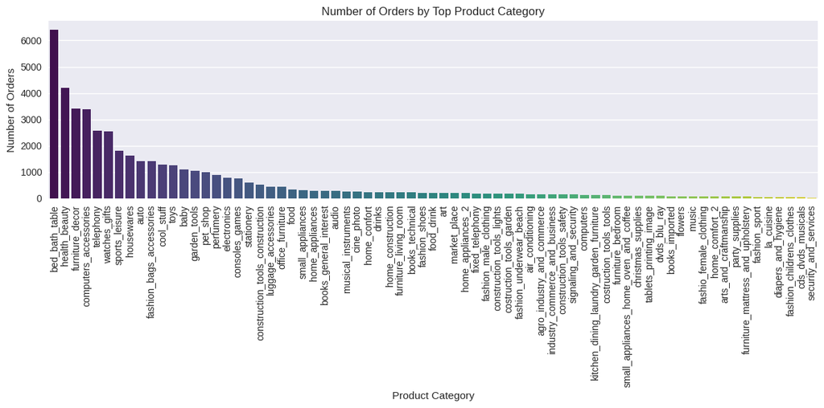

```python
# ANSWER: bar chart of product categories
category_counts = df_orders_cleaned['top_product_category'].value_counts()

plt.figure(figsize=(12, 6))
sns.barplot(x=category_counts.index, y=category_counts.values, palette='viridis')
plt.title('Number of Orders by Top Product Category')
plt.xlabel('Product Category')
plt.ylabel('Number of Orders')
plt.xticks(rotation=90)
plt.tight_layout()
plt.show()
```

#### Brief interpretation

**Task:**

- In 2–3 sentences, describe any trends you see (e.g., which categories dominate, whether the distribution is skewed, etc.).

### 2.3 Box Plot: Order Value vs Number of Items (2 mark)

#### Create box plot

**Task:**

- Create a box plot with:
  - X‑axis: `num_items`
  - Y‑axis: `order_total_value`
- Add a clear title and axis labels.

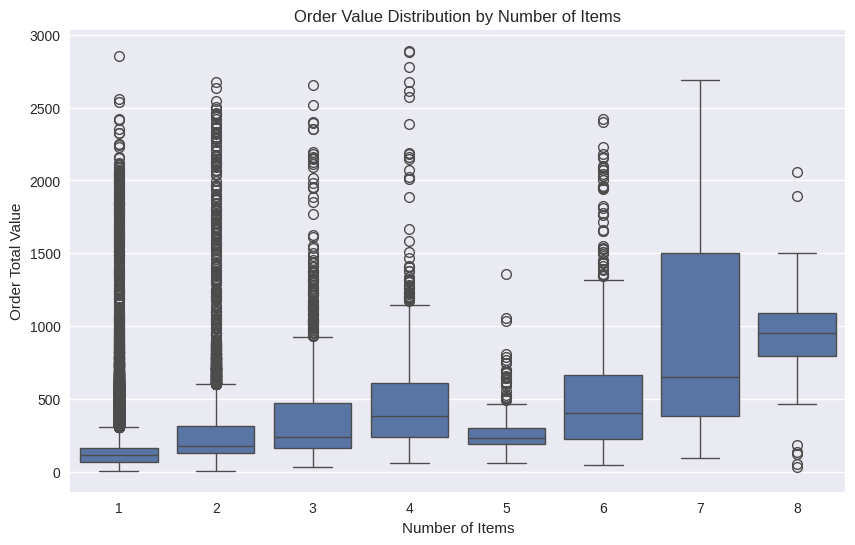

```python
# ANSWER: box plot order_total_value vs num_items
plt.figure(figsize=(10, 6))
sns.boxplot(x='num_items', y='order_total_value', data=df_orders_cleaned)

plt.title('Order Value Distribution by Number of Items')
plt.xlabel('Number of Items')
plt.ylabel('Order Total Value')

plt.show()
```

#### Brief interpretation

**Task:**

- In 2–3 sentences, describe how order value changes as the number of items increases (e.g., linear trend, diminishing returns, many outliers, etc.).

*Write your observations here.*

Based on the box plot, the median order value generally increases with the number of items,and the spread of values (variability) becomes much wider for larger orders. While single-item orders have the lowest median value, they contain a massive number of high-value outliers, indicating that expensive products are frequently purchased alone.

# Assignment 2: Supervised Learning Techniques for E-Commerce Orders

This notebook is your working template for **Assignment 2**.

**Total Marks: 30**

**Learning Objectives:**

- Apply essential data preprocessing techniques to a dataset for supervised learning
- Prepare the data for classification modeling
- Apply supervised learning techniques to build and evaluate classification models

**Your Objective:** Build supervised classification models to predict the **payment method (`payment_type`)** used for each order, based on order characteristics and order attributes.

Work **top-to-bottom**. Complete each task in order before moving on.

## Submitted by

Group number on Canvas:

| Student ID (AxxxxxxxZ) | NUSNet ID (exxxxxxx) | Name (as it appears on Canvas) |
| --- | --- | --- |
| A0328957J | e1553284@u.nus.edu | Liang Jing |
| A0328035J | e1546790@u.nus.edu | Shen Yitong |
| A0328839L | e1553166@u.nus.edu | Tay Dinghan |
| A0329062H | e1553389@u.nus.edu | Luo Shangyi |

## Setup

Run the cell below to import the required Python packages.

```python
import pandas as pd
import numpy as np
import matplotlib.pyplot as plt
import seaborn as sns
from google.colab import drive
drive.mount('/content/drive')

from sklearn.model_selection import train_test_split
from sklearn.preprocessing import StandardScaler, LabelEncoder
from sklearn.linear_model import LogisticRegression
from sklearn.tree import DecisionTreeClassifier
from sklearn.ensemble import RandomForestClassifier
from sklearn.svm import SVC
from sklearn.metrics import accuracy_score, precision_score, recall_score, f1_score, confusion_matrix, classification_report

import warnings
warnings.filterwarnings('ignore')

plt.style.use('ggplot')
```

## Define Global Random State

Set your group's random state value. This must be used consistently throughout the assignment.

```python
# TODO: Set RANDOM_STATE to your group number (1, 2, ..., 12)
RANDOM_STATE = 4  # Change this to your group number

print(f"Random state set to: {RANDOM_STATE}")
```

```
Random state set to: 4
```

# Part 1: Data Preparation [10 Marks]

In this section, you will prepare the transformed dataset for supervised classification. Proper data preparation is a critical step in the machine learning pipeline, as model performance and validity depend heavily on the quality, structure, and representation of the input data.

## 1.1 Data Loading and Splitting [2 Marks]

Load the dataset using Pandas and prepare train/test datasets.

**Instructions:**

1. Load the processed dataset from Assignment 1 using `pd.read_csv()`
2. Define features and target:
   - Set `payment_type` as the target variable
   - Set all remaining columns as input features
3. Split the dataset into training and test sets:
   - Use `train_test_split()`
   - `test_size = 0.2`
   - `random_state = RANDOM_STATE`
   - Name output variables as: `X_train`, `X_test`, `y_train`, `y_test`
4. Briefly explain the importance of using a test dataset.

```python
# Load the processed dataset from Assignment 1
# TODO: Adjust the filename/path if needed

df = pd.read_csv('/content/drive/MyDrive/ecommerce_orders_cleaned.csv')
print(f"Dataset shape: {df.shape}")
df.head()
```

```
Dataset shape: (46287, 17)
```

|  | order_id | order_status | order_purchase_hour | order_purchase_dayofweek | order_purchase_month | order_total_value | num_items | num_unique_products | num_unique_sellers | total_item_price | avg_item_price | total_freight_value | top_product_category | customer_state | payment_type | order_value_per_item | order_size_category |
| --- | --- | --- | --- | --- | --- | --- | --- | --- | --- | --- | --- | --- | --- | --- | --- | --- | --- |
| 0 | sdv-id-whzjUX | shipped | 10 | 4 | 4 | 744.312535 | 1 | 1 | 1 | 352.420029 | 369.966521 | 68.790159 | construction_tools_construction | Massachusetts | voucher | 352.420029 | Small |
| 1 | sdv-id-dbopoJ | delivered | 19 | 2 | 3 | 1556.667902 | 1 | 1 | 1 | 289.242639 | 1354.621410 | 15.394619 | health_beauty | Vermont | credit_card | 289.242639 | Small |
| 2 | sdv-id-FSEOvM | delivered | 15 | 4 | 8 | 62.060506 | 1 | 1 | 1 | 26.893468 | 48.485654 | 18.751282 | luggage_accessories | South Carolina | debit_card | 26.893468 | Small |
| 3 | sdv-id-bQcBUR | delivered | 21 | 0 | 8 | 73.873470 | 1 | 1 | 1 | 37.790896 | 75.704909 | 8.670875 | computers_accessories | Kentucky | credit_card | 37.790896 | Small |
| 4 | sdv-id-MPxIXB | delivered | 13 | 5 | 5 | 361.961537 | 3 | 3 | 3 | 169.528323 | 50.132979 | 34.731146 | pet_shop | Missouri | voucher | 56.509441 | Medium |

```python
# TODO: Define features and target, then split the data

# Define target variable
y = df['payment_type']

# Define features (all columns except payment_type)
X = df.drop(columns=['payment_type'])

# Split into train and test sets
X_train, X_test, y_train, y_test = train_test_split(X, y, test_size=0.2, random_state=42)

# Print shapes to verify
print(f"X_train shape: {X_train.shape}")
print(f"X_test shape: {X_test.shape}")
print(f"y_train shape: {y_train.shape}")
print(f"y_test shape: {y_test.shape}")
```

```
X_train shape: (37029, 16)
X_test shape: (9258, 16)
y_train shape: (37029,)
y_test shape: (9258,)
```

**TODO: Briefly explain the importance of using a test dataset.**

- The main reason why we need a test dataset is to check overfitting as overfitting or poor generalization can also lead to perfect model performance on train dataset.
- Other than that, the evalution metrics on the test dataset offers an objective and independent standard to compare different types of models.

## 1.2 Handling Categorical Variables [4 Marks]

Prepare categorical variables for machine learning.

**Instructions:**

1. Identify all categorical columns
2. Apply label encoding:
   - Use `LabelEncoder` from scikit-learn
3. Ensure consistency across train and test sets:
   - Fit encoders on training data only
   - Transform both train and test sets
   - Handle any unseen categories appropriately
4. Briefly explain why categorical encoding is required for machine learning models

```python
# TODO: Identify categorical columns

categorical_cols = X_train.select_dtypes(include=['object', 'category']).columns.tolist()
print(f"Categorical columns: {categorical_cols}")
```

```
Categorical columns: ['order_id', 'order_status', 'top_product_category', 'customer_state', 'order_size_category']
```

```python
# TODO: Apply Label Encoding to categorical columns

# Create copies to avoid modifying original data
X_train_encoded = X_train.copy()
X_test_encoded = X_test.copy()

# Dictionary to store label encoders for each column
label_encoders = {}

for col in categorical_cols:
    le = LabelEncoder()

    # Fit on training data
    le.fit(X_train_encoded[col].astype(str))

    # Transform train and test
    X_train_encoded[col] = le.transform(X_train_encoded[col].astype(str))

    # Handle unseen categories in test set
    known_classes = set(le.classes_)
    X_test_encoded[col] = X_test_encoded[col].astype(str).apply(
        lambda x: x if x in known_classes else le.classes_[0]
    )
    X_test_encoded[col] = le.transform(X_test_encoded[col])

    # Store encoder
    label_encoders[col] = le

# Print the shape after encoding
print(f"X_train_encoded shape: {X_train_encoded.shape}")
print(f"X_test_encoded shape: {X_test_encoded.shape}")
```

```
X_train_encoded shape: (37029, 16)
X_test_encoded shape: (9258, 16)
```

**TODO: Briefly explain why categorical encoding is required for machine learning models.**

- Most machine learning algorithms (like Linear Regression, SVMs, and Neural Networks) perform calculations using weighted sums and optimizations. Encoding transforms these text labels into numbers so the model can perform the necessary linear algebra and calculus.

## 1.3 Handling Numerical Variables [4 Marks]

Scale numerical variables for modeling.

**Instructions:**

1. Identify all numerical columns
2. Use `StandardScaler` from scikit-learn for feature scaling
3. **Fit the scaler on X_train only**
4. Transform both X_train and X_test
5. Briefly explain why feature scaling is important for some classification models

```python
# TODO: Identify numerical columns

numerical_cols = X_train.select_dtypes(include=['int64', 'float64']).columns.tolist()
print(f"Numerical columns: {numerical_cols}")
```

```
Numerical columns: ['order_purchase_hour', 'order_purchase_dayofweek', 'order_purchase_month', 'order_total_value', 'num_items', 'num_unique_products', 'num_unique_sellers', 'total_item_price', 'avg_item_price', 'total_freight_value', 'order_value_per_item']
```

```python
# TODO: Apply StandardScaler to numerical columns

scaler = StandardScaler()

# Fit on training data only, then transform both train and test
X_train_scaled = X_train_encoded.copy()
X_test_scaled = X_test_encoded.copy()

X_train_scaled[numerical_cols] = scaler.fit_transform(X_train_encoded[numerical_cols])
X_test_scaled[numerical_cols] = scaler.transform(X_test_encoded[numerical_cols])

# Print the shape after scaling
print(f"X_train_scaled shape: {X_train_scaled.shape}")
print(f"X_test_scaled shape: {X_test_scaled.shape}")
```

```
X_train_scaled shape: (37029, 16)
X_test_scaled shape: (9258, 16)
```

**TODO: Briefly explain why feature scaling is important for some classification models.**

- Many models like Logistic Regression use Gradient Descent as an optimization engine to find the minimum of the loss function. Scaling makes the loss function more spherical, allowing the gradient descent algorithm to take a more direct path to the global minimum, which leads to faster convergence.
- Algorithms like Support Vector Machines (SVM) calculate the distance between data points (usually Euclidean distance) to determine similarity or find a decision boundary. If one feature has a much larger range than others, the distance calculation will be dominated by that feature.

# Part 2: Applying Machine Learning Models [20 Marks]

In this section, you will train, evaluate, and compare multiple supervised classification models for predicting the payment method (`payment_type`). The objective is not only to build individual models, but also to perform a systematic comparison of their predictive performance and practical suitability for deployment.

## 2.1 Model Training

### 2.1.1 Logistic Regression [3 Marks]

Logistic Regression is a linear classification model that models the log-odds of the target class as a linear combination of the input features.

**Instructions:**

- Use `LogisticRegression()`
- Train on `X_train`, `y_train`
- Generate predictions on `X_test`
- Store the results in `y_pred_lr`

```python
# TODO: Train Logistic Regression model
lr_model = LogisticRegression(random_state=RANDOM_STATE, max_iter=1000)
lr_model.fit(X_train_scaled, y_train)

# Generate predictions
y_pred_lr = lr_model.predict(X_test_scaled)

print("Logistic Regression training complete.")
```

```
Logistic Regression training complete.
```

### 2.1.2 Decision Trees [3 Marks]

Decision Trees is a tree-structured model that makes predictions by recursively splitting the feature space based on feature values.

**Instructions:**

- Use `DecisionTreeClassifier()`
- Train on `X_train`, `y_train`
- Generate predictions on `X_test`
- Store the results in `y_pred_dt`

```python
# TODO: Train Decision Tree model

dt_model = DecisionTreeClassifier(random_state=RANDOM_STATE)
dt_model.fit(X_train_scaled, y_train)

# Generate predictions
y_pred_dt = dt_model.predict(X_test_scaled)

print("Decision Tree training complete.")
```

```
Decision Tree training complete.
```

### 2.1.3 Kernel & Ensemble Methods [3 Marks]

There are other types of models beyond linear and single-tree approaches, each with distinct characteristics.

**Choose one of the following models to apply:** SVM, XGBoost, or Random Forest.

**Instructions:**

- Fit and predict the results with your selected model
- Store the predictions appropriately

```python
# TODO: Train your chosen model (SVM, XGBoost, or Random Forest)
rf_model = RandomForestClassifier(random_state=RANDOM_STATE)
rf_model.fit(X_train_scaled, y_train)

y_pred_rf = rf_model.predict(X_test_scaled)

print("Random Forest Classifier training complete.")
```

```
Random Forest Classifier training complete.
```

## 2.2 Evaluation & Visualization [4 Marks]

Evaluate and visualize performance for all three models.

**Instructions:**

1. Compute the following metrics:
   - Accuracy
   - Precision
   - Recall
   - F1-score
2. Compute the confusion matrix for each case:
   - Visualize the confusion matrix by plotting a heatmap using Seaborn
3. Present results in a clear, comparable format:
   - Table of metrics for all three models
   - Side-by-side or clearly labelled confusion matrix plots
4. Briefly comment on:
   - Strengths and weaknesses of each model
   - Any impact of class imbalance handling

```python
# TODO: Compute evaluation metrics for all three models

def evaluate_model(y_true, y_pred, model_name):
    accuracy = accuracy_score(y_true, y_pred)
    precision = precision_score(y_true, y_pred, average='weighted')
    recall = recall_score(y_true, y_pred, average='weighted')
    f1 = f1_score(y_true, y_pred, average='weighted')

    return {
        'Model': model_name,
        'Accuracy': accuracy,
        'Precision': precision,
        'Recall': recall,
        'F1-Score': f1
    }
# Evaluate all models
results = [
    evaluate_model(y_test, y_pred_lr, 'Logistic Regression'),
    evaluate_model(y_test, y_pred_dt, 'Decision Tree'),
    evaluate_model(y_test, y_pred_rf, 'Random Forest')  # or your chosen model
]
# Create results DataFrame
results_df = pd.DataFrame(results)
results_df
```

|  | Model | Accuracy | Precision | Recall | F1-Score |
| --- | --- | --- | --- | --- | --- |
| 0 | Logistic Regression | 0.608339 | 0.513718 | 0.608339 | 0.487035 |
| 1 | Decision Tree | 0.438108 | 0.493485 | 0.438108 | 0.458538 |
| 2 | Random Forest | 0.624757 | 0.573429 | 0.624757 | 0.577230 |

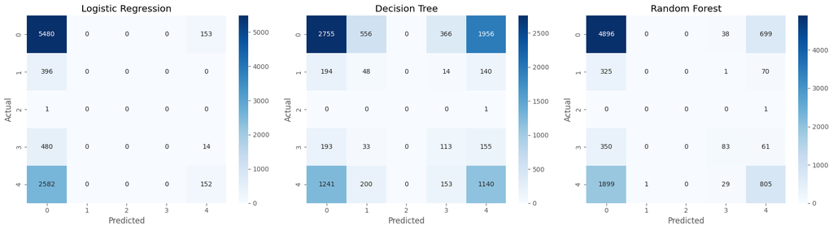

```python
# TODO: Plot confusion matrices for all three models

fig, axes = plt.subplots(1, 3, figsize=(18, 5))

def plot_confusion_matrix(y_true, y_pred, ax, title):
    cm = confusion_matrix(y_true, y_pred)
    sns.heatmap(cm, annot=True, fmt='d', cmap='Blues', ax=ax)
    ax.set_title(title)
    ax.set_xlabel('Predicted')
    ax.set_ylabel('Actual')

plot_confusion_matrix(y_test, y_pred_lr, axes[0], 'Logistic Regression')
plot_confusion_matrix(y_test, y_pred_dt, axes[1], 'Decision Tree')
plot_confusion_matrix(y_test, y_pred_rf, axes[2], 'Random Forest')  # or your chosen model
plt.tight_layout()
plt.show()
```

**TODO: Briefly comment on the strengths and weaknesses of each model, and any impact of class imbalance handling.**

Logistic Regression:

Strengths: Highly interpretable (linear coefficients), computationally efficient, good baseline.  
Weaknesses: Assumes linearity, less robust to complex relationships and outliers, moderate performance (F1=0.487).

Decision Tree:

Strengths: Highly interpretable (if-then rules), handles non-linear relationships, no feature scaling needed.  
Weaknesses: Prone to overfitting (lowest F1=0.4585), unstable, can be biased by class imbalance.

Random Forest:

Strengths: High accuracy (best F1=0.5772), reduces overfitting, robust to noise, handles non-linear data well.  
Weaknesses: Less interpretable than single trees/logistic regression, more computationally intensive.

Regarding class imbalance handling, if stratification was used during the train-test split, it helps ensure all classes are represented. The use of 'weighted' evaluation metrics (like F1-score) also helps to account for class distribution differences, showing how well a model performs across all classes, including minority ones. If class imbalance is significant and not properly addressed, models might perform poorly on minority classes.

## 2.3 Model Selection & Final Recommendation [7 Marks]

Compare the performance of the models and select the most suitable one based on evaluation results.

**Instructions:**

1. Select the best performing model for predicting `payment_type`
2. Justify your choice based on:
   - Evaluation metrics
   - Class imbalance considerations
   - Model complexity and interpretability
   - Practical deployment considerations
3. Briefly explain why this model is preferred over the others
4. Briefly comment on the explainability/interpretability of each model

```python
# TODO: Display final comparison and analysis

# Display the results table
print("Model Performance Comparison:")
print(results_df.to_string(index=False))

# Identify the best model based on your criteria
best_model = results_df.loc[results_df['F1-Score'].idxmax(), 'Model']
print(f"\nBest performing model: {best_model}")
```

```
Model Performance Comparison:
              Model  Accuracy  Precision   Recall  F1-Score
Logistic Regression  0.608339   0.513718 0.608339  0.487035
      Decision Tree  0.438108   0.493485 0.438108  0.458538
      Random Forest  0.624757   0.573429 0.624757  0.577230

Best performing model: Random Forest
```

### Final Recommendation

**TODO: Select and justify your choice of the best model.**

**Selected Model:** Random Forest

**Justification based on:**

**Why this model is preferred over others:** Random Forest is preferred because it delivers the strongest and most balanced predictive performance in this experiment (especially weighted F1), while remaining practical and reliable for real-world tabular classification. Logistic Regression is simpler but underperforms on balanced effectiveness, and a single Decision Tree is easier to interpret but less stable and less accurate overall.

### Model Explainability/Interpretability

**TODO: Comment on the explainability/interpretability of each model.**

**Logistic Regression:**

- Logistic Regression is highly interpretable because each feature has a coefficient that indicates both the direction (+/-) and strength of its effect on the predicted payment type.
- Its linear decision boundary makes the model behavior easy to explain to non-technical stakeholders, but it may miss complex non-linear interactions in e-commerce data.

**Decision Tree:**

- Decision trees are highly interpretable because they mimic human decision-making processes through a sequence of hierarchical "if-then" rules.
- While easy to visualize, the decision tree performed the worst in this experiment (Accuracy: 0.438), likely due to its tendency to overfit the training noise in the e-commerce dataset. It is sensitive to small fluctuations in the data, making it less robust than the Random Forest ensemble.

**Random Forest:**

- The essence of Random Forest is the integration of multiple trees, so we cannot explain a single prediction but can globally interpret by using feature importance or confusion matrix.
- In our payment method classification task, the Random Forest model effectively captures dominant patterns in order characteristics, especially for majority payment types, but lacks transparency in explaining predictions for minority classes.

## Conclusion

- Essential steps like LabelEncoder for categorical features and StandardScaler for numerical attributes were implemented to ensure the data was compatible with various algorithms, particularly Logistic Regression.
- Among the three models tested, Random Forest demonstrated superior predictive power with an accuracy of approximately 62.5% and the highest weighted F1-score (0.577). Logistic Regression provided a stable baseline, while the single Decision Tree struggled with generalization.
- There is a clear trade-off between performance and explainability. Logistic Regression offers the most direct interpretation of feature effects through coefficients, whereas Random Forest provides the best accuracy by capturing complex non-linear relationships at the cost of direct path transparency.

**Key Takeaway**: For this specific e-commerce task, ensemble methods like Random Forest are most suitable for deployment, as they provide a significant performance boost while still offering global interpretability through feature importance analysis

# Project (Assignment 3): Unsupervised Learning (E-Commerce Orders)

This notebook is your working template for **Assignment 3**.

**Note:** This assessment comprises two parts: question-guided processing/modeling (Unsupervised learning) and free-form exploration.

**Total Marks: 20**

You will:

- Continue working with the expanded dataset from Assignment 1
- Perform **clustering** to identify similar order types
- Apply **market basket analysis** (association rule mining)
- Write up findings throughout the notebook
- Publish your analysis as a github.io page

Work **top-to-bottom**. Complete each task in order before moving on.

## Submitted by

Group number on Canvas:

| Student ID (AxxxxxxxZ) | NUSNet ID (exxxxxxx) | Name (as it appears on Canvas) |
| --- | --- | --- |
| A0328957J | e1553284@u.nus.edu | Liang Jing |
| A0328035J | e1546790@u.nus.edu | Shen Yitong |
| A0328839L | e1553166@u.nus.edu | Tay Dinghan |
| A0329062H | e1553389@u.nus.edu | Luo Shangyi |

## Setup

Run the cell below to import the required Python packages.

```python
import pandas as pd
import numpy as np
import matplotlib.pyplot as plt
import seaborn as sns
import warnings

from sklearn.model_selection import train_test_split
from sklearn.preprocessing import StandardScaler
from sklearn.cluster import KMeans

from mlxtend.preprocessing import TransactionEncoder
from mlxtend.frequent_patterns import apriori, association_rules

warnings.filterwarnings("ignore", category=DeprecationWarning)

plt.style.use('seaborn-v0_8')
```

## Load Your Cleaned Dataset from Assignment 1

Load the cleaned and expanded dataset you created in Assignment 1 (and potentially modified in Assignment 2).

```python
# ANSWER: Load your cleaned dataset
from google.colab import drive
drive.mount('/content/drive')
df = pd.read_csv('/content/drive/MyDrive/ecommerce_orders_cleaned.csv')
```

## Task: Unsupervised Learning

### Objective

In this task, you will work on unsupervised learning and support your analysis with visualization. Perform clustering to identify **similar orders** and generate **order type recommendations** based on their characteristics. An order type cluster represents a group of orders with similar purchasing patterns, value structures, and composition.

### 1: Data Preprocessing for Unsupervised Learning [1 Mark]

Goal: Create DataFrames that contain one row per order with features suitable for both clustering and association mining.

#### 1.1 Create `all_orders_df` (one row per order)

Create a new DataFrame called `all_orders_df` with the following columns:

Identifier:

- `order_id` — Unique identifier of the order
- `basket_size` — Monetary value of the order (from `order_total_value`)
- `basket_qty` — Number of items in the order (from `num_items`)
- `freight_ratio` — Proportion of the order value that is freight (computed as `total_freight_value / order_total_value`)
- `product_diversity` — How varied the basket is in terms of product types (computed as `num_unique_products / num_items`)
- `top_product_category` — The dominant product category in the order
- `payment_type` — The payment method used
- `order_size_category` — The order size category (Small/Medium/Large)

Notes:

- `all_orders_df` must have exactly one row per `order_id`.
- No missing values should remain in these columns after preprocessing (apply reasonable handling if needed).
- Handle potential division issues appropriately (e.g., orders with zero values).
- Display the first 10 rows of `all_orders_df`, its shape, and data types.

```python
# 1.1 ANSWER: Create all_orders_df
all_orders_df = df.groupby('order_id').agg({
    'order_total_value': 'sum',
    'num_items': 'sum',
    'total_freight_value': 'sum',
    'num_unique_products': 'sum',
    'top_product_category': 'first',
    'payment_type': 'first',
    'order_size_category': 'first'
}).reset_index()

all_orders_df = all_orders_df.rename(columns={
    'order_total_value': 'basket_size',
    'num_items': 'basket_qty'
})

all_orders_df['freight_ratio'] = (
    all_orders_df['total_freight_value'] / all_orders_df['basket_size']
).fillna(0).replace([np.inf, -np.inf], 0)

all_orders_df['product_diversity'] = (
    all_orders_df['num_unique_products'] / all_orders_df['basket_qty']
).fillna(0).replace([np.inf, -np.inf], 0)

final_cols = [
    'order_id', 'basket_size', 'basket_qty', 'freight_ratio',
    'product_diversity', 'top_product_category', 'payment_type', 'order_size_category'
]
all_orders_df = all_orders_df[final_cols]

print(f"--- DataFrame Shape ---\n{all_orders_df.shape}\n")
print(f"--- Data Types ---\n{all_orders_df.dtypes}\n")
print("--- First 10 rows of all_orders_df ---")
print(all_orders_df.head(10))
```

```
--- DataFrame Shape ---
(46287, 8)

--- Data Types ---
order_id                 object
basket_size             float64
basket_qty                int64
freight_ratio           float64
product_diversity       float64
top_product_category     object
payment_type             object
order_size_category      object
dtype: object

--- First 10 rows of all_orders_df ---
        order_id  basket_size  basket_qty  freight_ratio  product_diversity  \
0  sdv-id-AAClGc    93.818314           1       0.132907                1.0
1  sdv-id-AAMmEf   320.933418           1       0.049904                1.0
2  sdv-id-AANLuW   598.264149           4       0.119390                1.0
3  sdv-id-AASEnv   116.107199           2       0.166356                1.0
4  sdv-id-AATUAB   119.782068           2       0.191747                1.0
5  sdv-id-AAWggC   102.764778           1       0.151897                1.0
6  sdv-id-AAZaWF   132.588964           1       0.352365                1.0
7  sdv-id-AAZhzH   133.916690           3       0.325442                1.0
8  sdv-id-AAaVPe   150.874812           1       0.106391                1.0
9  sdv-id-AAbZFT   648.169000           2       0.044244                1.0

    top_product_category payment_type order_size_category
0         bed_bath_table  credit_card               Small
1         bed_bath_table  credit_card               Small
2        furniture_decor  credit_card              Medium
3         sports_leisure  credit_card               Small
4         bed_bath_table  credit_card               Small
5                   toys  credit_card               Small
6         bed_bath_table      voucher               Small
7        furniture_decor      voucher              Medium
8  computers_accessories      voucher               Small
9         bed_bath_table  credit_card               Small
```

#### 1.2 Create `orders_analysis_df`

- Use `train_test_split` from sklearn to split the data in `all_orders_df`.
- Set `test_size=0.3` (keep 30% of data for analysis) and `random_state=37` for reproducibility.
- Assign the **test set** to the variable `orders_analysis_df`.

Display the shape of `orders_analysis_df` and show its first 10 rows.

```python
# 1.2 ANSWER: Create orders_analysis_df using train_test_split

_, orders_analysis_df = train_test_split(all_orders_df, test_size=0.3, random_state=37)

print(f"Shape of orders_analysis_df: {orders_analysis_df.shape}\n")
print("First 10 rows of orders_analysis_df:")
display(orders_analysis_df.head(10))
```

```
Shape of orders_analysis_df: (13887, 8)

First 10 rows of orders_analysis_df:
```

|  | order_id | basket_size | basket_qty | freight_ratio | product_diversity | top_product_category | payment_type | order_size_category |
| --- | --- | --- | --- | --- | --- | --- | --- | --- |
| 1882 | sdv-id-CHJjQG | 138.676915 | 1 | 0.095680 | 1.000000 | books_technical | voucher | Small |
| 40995 | sdv-id-uIGruU | 262.552656 | 2 | 0.165603 | 0.500000 | garden_tools | voucher | Small |
| 40104 | sdv-id-tJQnBQ | 559.441467 | 3 | 0.212141 | 0.666667 | sports_leisure | credit_card | Medium |
| 25808 | sdv-id-cwqCaM | 72.241546 | 2 | 0.210252 | 1.000000 | health_beauty | voucher | Small |
| 23294 | sdv-id-aEQyqe | 374.585906 | 1 | 0.047288 | 1.000000 | home_confort | credit_card | Small |
| 7160 | sdv-id-HxoxwT | 1548.278388 | 7 | 0.114368 | 1.000000 | furniture_decor | voucher | Large |
| 7180 | sdv-id-HyldrL | 173.977881 | 1 | 0.110791 | 1.000000 | garden_tools | voucher | Small |
| 20801 | sdv-id-XPPcxk | 183.242142 | 1 | 0.233787 | 1.000000 | bed_bath_table | credit_card | Small |
| 19879 | sdv-id-WLknoq | 129.674951 | 3 | 0.114825 | 1.000000 | housewares | credit_card | Medium |
| 39874 | sdv-id-suaNKw | 169.934776 | 1 | 0.099724 | 1.000000 | bed_bath_table | credit_card | Small |

### 2: Determine the Optimal Number of Clusters [3 Marks]

#### 2.1 Run K-Means for Different Cluster Numbers

- Use **only the four numerical features** from `orders_analysis_df` (`basket_size`, `basket_qty`, `freight_ratio`, `product_diversity`) for clustering.
- Run K-means clustering from **k = 3 to 9** clusters.
- Important: First scale the numerical features using `StandardScaler` before fitting K-means.
- In each run, calculate the **inertia** of the cluster and store the values for each k (3 to 9) in a list or table.

Inertia is a measure of how tightly packed the clusters are. It is the sum of squared distances between each point and its assigned cluster center (centroid). Lower inertia indicates that the clusters are more compact, and the points are closer to their centroids, suggesting better clustering.

```python
# 2.1 ANSWER: Run K-means for k=3 to 9 and calculate inertia

Z = orders_analysis_df[['basket_size', 'basket_qty', 'freight_ratio', 'product_diversity']]
scaler = StandardScaler()
Z_scaled = scaler.fit_transform(Z)

inertia_values = []
k_range = range(3, 10) # K from 3 to 9

for k in k_range:
    kmeans = KMeans(n_clusters=k, random_state=37, n_init=10) # Set n_init to suppress warning
    kmeans.fit(Z_scaled)
    inertia_values.append(kmeans.inertia_)

print("Inertia values for k=", list(k_range), ":", inertia_values)
```

```
Inertia values for k= [3, 4, 5, 6, 7, 8, 9] : [28860.457013803803, 21578.631079869807, 17668.968361133255, 15358.32945971075, 13626.10659736509, 12161.582730964778, 10843.868481065516]
```

#### 2.2 Elbow Method for Optimal Clusters

- Plot the **inertia** (y-axis) against the **number of clusters** (x-axis) to identify the optimal number of clusters using the **Elbow method**.

The Elbow Method helps in selecting the number of clusters by identifying where the inertia starts to decrease more slowly.

- Based on the Elbow plot, **choose the optimal number of clusters** and state your choice clearly.

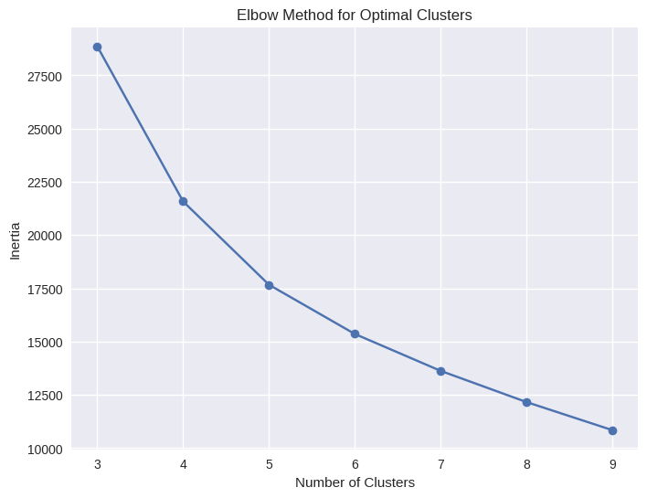

```
Based on the Elbow plot, an optimal number of clusters appears to be around k=5.
```

```python
# 2.2 ANSWER: Create Elbow plot

plt.figure(figsize=(8, 6))
plt.plot(k_range, inertia_values, marker='o', linestyle='-')
plt.title('Elbow Method for Optimal Clusters')
plt.xlabel('Number of Clusters')
plt.ylabel('Inertia')
plt.xticks(list(k_range))
plt.grid(True)
plt.show()

print("Based on the Elbow plot, an optimal number of clusters appears to be around k=5.")
```

### 3: Cluster Analysis and Visualization [3 Marks]

#### 3.1 Identify the Cluster Number for Each Order

- Create a K-means model using the four numerical features from `all_orders_df` and the optimal number of clusters identified in Task 2.
- Fit the model on the scaled numerical features.
- Use the fitted model to assign a cluster number to each order and add a new column called `cluster` to `all_orders_df`.
- Show the first 10 rows of `all_orders_df` to verify cluster assignment.

```python
# 3.1 ANSWER: Fit K-means with optimal k and assign clusters

numerical_features = [
    'basket_size', 'basket_qty', 'freight_ratio', 'product_diversity'
]
X_all_orders = all_orders_df[numerical_features]

scaler_all = StandardScaler()
X_all_orders_scaled = scaler_all.fit_transform(X_all_orders)

kmeans_optimal = KMeans(n_clusters=5, random_state=37, n_init=10)
kmeans_optimal.fit(X_all_orders_scaled)

all_orders_df['cluster'] = kmeans_optimal.labels_

print("--- First 10 rows of all_orders_df with cluster assignment ---")
display(all_orders_df.head(10))
```

```
--- First 10 rows of all_orders_df with cluster assignment ---
```

|  | order_id | basket_size | basket_qty | freight_ratio | product_diversity | top_product_category | payment_type | order_size_category | cluster |
| --- | --- | --- | --- | --- | --- | --- | --- | --- | --- |
| 0 | sdv-id-AAClGc | 93.818314 | 1 | 0.132907 | 1.0 | bed_bath_table | credit_card | Small | 0 |
| 1 | sdv-id-AAMmEf | 320.933418 | 1 | 0.049904 | 1.0 | bed_bath_table | credit_card | Small | 0 |
| 2 | sdv-id-AANLuW | 598.264149 | 4 | 0.119390 | 1.0 | furniture_decor | credit_card | Medium | 2 |
| 3 | sdv-id-AASEnv | 116.107199 | 2 | 0.166356 | 1.0 | sports_leisure | credit_card | Small | 0 |
| 4 | sdv-id-AATUAB | 119.782068 | 2 | 0.191747 | 1.0 | bed_bath_table | credit_card | Small | 0 |
| 5 | sdv-id-AAWggC | 102.764778 | 1 | 0.151897 | 1.0 | toys | credit_card | Small | 0 |
| 6 | sdv-id-AAZaWF | 132.588964 | 1 | 0.352365 | 1.0 | bed_bath_table | voucher | Small | 1 |
| 7 | sdv-id-AAZhzH | 133.916690 | 3 | 0.325442 | 1.0 | furniture_decor | voucher | Medium | 1 |
| 8 | sdv-id-AAaVPe | 150.874812 | 1 | 0.106391 | 1.0 | computers_accessories | voucher | Small | 0 |
| 9 | sdv-id-AAbZFT | 648.169000 | 2 | 0.044244 | 1.0 | bed_bath_table | credit_card | Small | 0 |

#### 3.2 Visualize the Clusters

Create two visualizations to understand your clusters:

- **Visualization 1: Cluster Profile Heatmap**
  - Visualize the cluster profiles using a heatmap to understand the average characteristics of each segment.
  - Step 1: Compute the mean of the four numerical features (`basket_size`, `basket_qty`, `freight_ratio`, `product_diversity`) for each cluster.
  - Step 2: Scale these means (e.g., using `StandardScaler` to calculate Z-scores) so that different units (price vs. count) can be compared directly.
  - Step 3: Plot the scaled means as a heatmap:
    - X-axis: Cluster number
    - Y-axis: Feature name
    - Color: Use a diverging colormap (e.g., `RdBu_r`) to distinguish features that are above average (positive Z-score) from those that are below average (negative Z-score)
    - Annotation: Display the Z-score values in each cell
  - Add a clear title.
- **Visualization 2: Cluster Size Distribution**
  - Create a bar chart showing the number of orders in each cluster.
    - X-axis: Cluster number (0, 1, 2, ...)
    - Y-axis: Count of orders
    - This helps you understand if clusters are balanced or if some clusters dominate.
  - Add a title and axis labels.

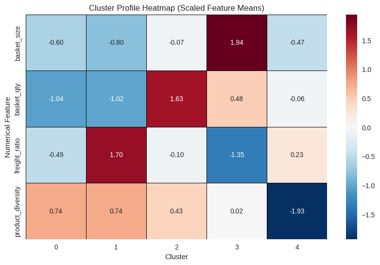

```python
# 3.2 ANSWER: Visualization 1 - Cluster profile heatmap

cluster_means = all_orders_df.groupby('cluster')[numerical_features].mean()

scaler_cluster_means = StandardScaler()
cluster_means_scaled = scaler_cluster_means.fit_transform(cluster_means)

cluster_means_scaled_df = pd.DataFrame(
    cluster_means_scaled,
    columns=numerical_features,
    index=cluster_means.index
)

plt.figure(figsize=(10, 6))
sns.heatmap(
    cluster_means_scaled_df.T,
    cmap='RdBu_r',
    annot=True,
    fmt=".2f",
    linewidths=.5,
    linecolor='black'
)
plt.title('Cluster Profile Heatmap (Scaled Feature Means)')
plt.xlabel('Cluster')
plt.ylabel('Numerical Feature')
plt.show()
```

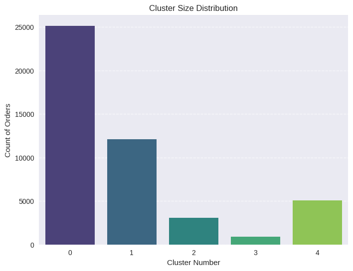

```python
# 3.2 ANSWER: Visualization 2 - Cluster size distribution

cluster_sizes = all_orders_df['cluster'].value_counts().sort_index()

plt.figure(figsize=(8, 6))
sns.barplot(x=cluster_sizes.index, y=cluster_sizes.values, palette='viridis')
plt.title('Cluster Size Distribution')
plt.xlabel('Cluster Number')
plt.ylabel('Count of Orders')
plt.xticks(cluster_sizes.index)
plt.grid(axis='y', linestyle='--', alpha=0.7)
plt.show()
```

**Briefly comment (2-3 sentences) on:**

- How well separated do the clusters appear based on the heatmap?
- Which features seem to have the most significant impact on defining the clusters? Why might this be the case?
- Based on the visualizations that you have generated, comment on the nature of the clusters and what it implies for an e-commerce business

### 4: Market Basket Analysis (Association Rule Mining) [8 Marks]

#### 4.1 Context: What is Market Basket Analysis?

Market Basket Analysis is an unsupervised learning technique that identifies which products, categories, or attributes are frequently observed together. In e-commerce, this helps answer questions such as:

- "Which payment methods are preferred for which product categories?"
- "Do certain order sizes correlate with specific product types?"
- "What are the multi-dimensional patterns across category, payment, and order size?"

Association rules are commonly described using three key metrics:

- **Support**: How frequently a pattern occurs (0-1 scale)
- **Confidence**: Likelihood of the consequent given the antecedent (0-1 scale)
- **Lift**: How much more likely the rule is compared to random chance (> 1 indicates a positive association)

The Apriori algorithm discovers frequent itemsets and then generates association rules from them.

In this task, you will perform Market Basket Analysis using the categorical features from `all_orders_df` to discover multi-dimensional associations between product category, payment type, and order size category.

#### 4.2 Prepare Transaction Data [1 Mark]

Convert each order in `all_orders_df` into a simple "basket" representation.

Create a Python list called `transactions`, where each element represents one order and contains exactly three string items constructed from that order:

- `cat_{top_product_category}` (e.g., `cat_electronics`, `cat_furniture_decor`)
- `pay_{payment_type}` (e.g., `pay_credit_card`, `pay_boleto`)
- `size_{order_size_category}` (e.g., `size_Small`, `size_Large`)

After constructing `transactions`, display the first 5 transactions to verify the format.

```python
# 4.2 ANSWER: Create transaction list

transactions = all_orders_df.apply(
    lambda row: [
        f"cat_{row['top_product_category']}",
        f"pay_{row['payment_type']}",
        f"size_{row['order_size_category']}"
    ],
    axis=1
).tolist()

print("First 5 transactions:")
for i, t in enumerate(transactions[:5], start=1):
    print(f"{i}: {t}")
```

```
First 5 transactions:
1: ['cat_bed_bath_table', 'pay_credit_card', 'size_Small']
2: ['cat_bed_bath_table', 'pay_credit_card', 'size_Small']
3: ['cat_furniture_decor', 'pay_credit_card', 'size_Medium']
4: ['cat_sports_leisure', 'pay_credit_card', 'size_Small']
5: ['cat_bed_bath_table', 'pay_credit_card', 'size_Small']
```

#### 4.3 Encode Transactions and Apply Apriori Algorithm [2 Marks]

Use the `mlxtend` library to discover frequent itemsets and generate association rules.

- Step 1: Encode transactions using `TransactionEncoder` and display the shape of the encoded DataFrame.
- Step 2: Apply `apriori()` with `min_support = 0.01` and `use_colnames = True`, then display the number of frequent itemsets found.
- Step 3: Generate association rules using `association_rules()` with `metric = 'lift'` and `min_threshold = 1.0`, then display the number of rules generated.

```python
# 4.3 ANSWER: Step 1 - Encode transactions

te = TransactionEncoder()
te_ary = te.fit(transactions).transform(transactions)
transaction_df = pd.DataFrame(te_ary, columns=te.columns_)

print("Encoded transaction DataFrame shape:", transaction_df.shape)
transaction_df.head()
```

```
Encoded transaction DataFrame shape: (46287, 79)
```

|  | cat_agro_industry_and_commerce | cat_air_conditioning | cat_art | cat_arts_and_craftmanship | cat_audio | cat_auto | cat_baby | cat_bed_bath_table | cat_books_general_interest | cat_books_imported | ... | cat_toys | cat_watches_gifts | pay_credit_card | pay_debit_card | pay_not_defined | pay_points | pay_voucher | size_Large | size_Medium | size_Small |
| --- | --- | --- | --- | --- | --- | --- | --- | --- | --- | --- | --- | --- | --- | --- | --- | --- | --- | --- | --- | --- | --- |
| 0 | False | False | False | False | False | False | False | True | False | False | ... | False | False | True | False | False | False | False | False | False | True |
| 1 | False | False | False | False | False | False | False | True | False | False | ... | False | False | True | False | False | False | False | False | False | True |
| 2 | False | False | False | False | False | False | False | False | False | False | ... | False | False | True | False | False | False | False | False | True | False |
| 3 | False | False | False | False | False | False | False | False | False | False | ... | False | False | True | False | False | False | False | False | False | True |
| 4 | False | False | False | False | False | False | False | True | False | False | ... | False | False | True | False | False | False | False | False | False | True |

5 rows × 79 columns

```python
# 4.3 ANSWER: Step 2 - Apply Apriori

frequent_itemsets = apriori(transaction_df, min_support=0.01, use_colnames=True)

print("Number of frequent itemsets found:", len(frequent_itemsets))
frequent_itemsets.head()
```

```
Number of frequent itemsets found: 102
```

|  | support | itemsets |
| --- | --- | --- |
| 0 | 0.030592 | (cat_auto) |
| 1 | 0.023592 | (cat_baby) |
| 2 | 0.138678 | (cat_bed_bath_table) |
| 3 | 0.073152 | (cat_computers_accessories) |
| 4 | 0.016311 | (cat_consoles_games) |

```python
# 4.3 ANSWER: Step 3 - Generate association rules

rules = association_rules(frequent_itemsets, metric='lift', min_threshold=1.0)

print("Number of association rules generated:", len(rules))
rules.head()
```

```
Number of association rules generated: 138
```

|  | antecedents | consequents | antecedent support | consequent support | support | confidence | lift | representativity | leverage | conviction | zhangs_metric | jaccard | certainty | kulczynski |
| --- | --- | --- | --- | --- | --- | --- | --- | --- | --- | --- | --- | --- | --- | --- |
| 0 | (pay_credit_card) | (cat_auto) | 0.604641 | 0.030592 | 0.020503 | 0.033909 | 1.108423 | 1.0 | 0.002006 | 1.003433 | 0.247414 | 0.033352 | 0.003422 | 0.352053 |
| 1 | (cat_auto) | (pay_credit_card) | 0.030592 | 0.604641 | 0.020503 | 0.670198 | 1.108423 | 1.0 | 0.002006 | 1.198777 | 0.100904 | 0.033352 | 0.165817 | 0.352053 |
| 2 | (cat_baby) | (pay_credit_card) | 0.023592 | 0.604641 | 0.015015 | 0.636447 | 1.052604 | 1.0 | 0.000750 | 1.087487 | 0.051182 | 0.024486 | 0.080449 | 0.330640 |
| 3 | (pay_credit_card) | (cat_baby) | 0.604641 | 0.023592 | 0.015015 | 0.024833 | 1.052604 | 1.0 | 0.000750 | 1.001273 | 0.126403 | 0.024486 | 0.001271 | 0.330640 |
| 4 | (size_Small) | (cat_baby) | 0.864735 | 0.023592 | 0.020913 | 0.024184 | 1.025108 | 1.0 | 0.000512 | 1.000607 | 0.181074 | 0.024110 | 0.000607 | 0.455316 |

#### 4.4 Extract and Display Top 10 Rules [1 Mark]

Sort the association rules by **lift** in descending order and display the top 10 rules in a table showing:

- Antecedents (left-hand side of rule)
- Consequents (right-hand side of rule)
- Support
- Confidence
- Lift

Example rule output and interpretation:

| antecedents | consequents | support | confidence | lift |
| --- | --- | --- | --- | --- |
| (cat_furniture_decor, size_Large) | (pay_credit_card) | 0.042 | 0.756 | 1.84 |

"Customers who purchase **furniture** in **large orders** have a **75.6% probability** (confidence) of paying with a **credit card**. This behavior is **1.84 times more likely** (lift) than the general probability of using a credit card.

```python
# 4.4 ANSWER: Display top 10 rules by lift

top_10_rules = (
    rules.sort_values(by='lift', ascending=False)
    .head(10)
    .copy()
)

# Convert frozenset to sorted, comma-separated strings for readability
top_10_rules['antecedents'] = top_10_rules['antecedents'].apply(lambda x: ', '.join(sorted(list(x))))
top_10_rules['consequents'] = top_10_rules['consequents'].apply(lambda x: ', '.join(sorted(list(x))))

display(
    top_10_rules[
        ['antecedents', 'consequents', 'support', 'confidence', 'lift']
    ].reset_index(drop=True)
)
```

|  | antecedents | consequents | support | confidence | lift |
| --- | --- | --- | --- | --- | --- |
| 0 | size_Large | cat_furniture_decor | 0.014583 | 0.392899 | 5.328480 |
| 1 | cat_furniture_decor | size_Large | 0.014583 | 0.197773 | 5.328480 |
| 2 | cat_bed_bath_table | pay_credit_card, size_Medium | 0.016851 | 0.121514 | 2.023212 |
| 3 | pay_credit_card, size_Medium | cat_bed_bath_table | 0.016851 | 0.280576 | 2.023212 |
| 4 | size_Medium | cat_bed_bath_table, pay_credit_card | 0.016851 | 0.171693 | 1.757439 |
| 5 | cat_bed_bath_table, pay_credit_card | size_Medium | 0.016851 | 0.172490 | 1.757439 |
| 6 | cat_furniture_decor | size_Medium | 0.012660 | 0.171696 | 1.749354 |
| 7 | size_Medium | cat_furniture_decor | 0.012660 | 0.128990 | 1.749354 |
| 8 | cat_bed_bath_table | size_Medium | 0.022749 | 0.164044 | 1.671388 |
| 9 | size_Medium | cat_bed_bath_table | 0.022749 | 0.231785 | 1.671388 |

#### 4.5 Interpretation (3-4 sentences) [3 Marks]

Write a brief interpretation explaining:

- What the top 3 unique rules tell you about customer behavior
- Which combinations are most strongly associated (highest lift)
- Why these associations might exist (business intuition)
- Change the min_support value to 0.005 and 0.3 and comment on any changes in the rules identified

#### 4.6 Business Recommendations (2-3 bullet points) [1 Mark]

Based on the discovered associations, provide actionable business recommendations for an e-commerce firm.

**4.6 ANSWER:**

- **Targeted Logistics & Shipping Offers:** Since Furniture & Decor is strongly associated with Large orders (Lift > 5), the firm should offer "Tiered Shipping" incentives (e.g., "Free White-Glove Delivery for Furniture orders over $X"). Additionally, logistics operations should be optimized specifically for this category, as these orders are predictably bulky and high-value, requiring different handling than standard packages.
- **Payment Method Promotions for Home Goods:** The analysis shows a strong preference for Credit Card payments among customers buying Bed, Bath & Table products (Medium size). The marketing team should partner with credit card providers to offer specific cashback rewards or interest-free installment plans for this category to increase conversion rates and basket size.
- **Strategic Bundling:** Create "Room Refresh" bundles that combine Furniture (High lift with Large size) with smaller Decor items. This strategy leverages the natural tendency of furniture buyers to place large orders, encouraging them to add higher-margin accessories to their cart to reach a "Large" order threshold for potential discounts.

#### Tips

- Rules with **lift > 1.5** are considered strong associations; rules with **lift > 2.0** are very strong.
- When writing interpretations, explain not just the statistical strength but also the **business logic** behind the patterns.

## Task: Report (5 Marks)

### Objective

(Note: No separate report submission is required.) The report comprises the write-up that you have been working on within this iPython notebook. The write-up/report should clearly describe the steps performed and the reasoning behind each processing done for all the tasks from Assignment 1 until Association mining above.

### 1: Write-up / Report

Describe the steps performed and the reasoning behind each processing step for all tasks you have worked on so far:

- Assignment 1 (data cleaning and preprocessing)
- Assignment 2 (supervised learning)
- Assignment 3 (unsupervised learning)

Include your explanations inline near the cells where processing is done, and keep your descriptions concise but clear. Connect each analysis step to business objectives where appropriate.

# Assignment 1

This Assignment focused on consolidating and cleaning the raw e-commerce data to build a reliable foundation for all subsequent modelling in Assignment 2 and 3.

## Section 1.1 Data Loading & Joining

This loaded the datasets from CSV files into Pandas DataFrames. We inspected using .head() to understand the raw structure of the tables before combining them. We then consolidated the tables into a single dataset named df_orders_full.  
Companies often store data in heavily normalised databases (separate tables for financial tracking, logistics, and user actions etc). Joining these tables creates a unified view of a single transaction.

## Section 1.2 Data Cleaning

We handled missing values in numerical columns and imputed using the median of the respective column. Missing data in categorical columns was replaced using the mode (most frequent value). Any rows that still lacked a valid order_id or payment_type after imputation were completely dropped. The dataset was filtered to keep only valid transactions by removing rows where num_items or order_total_value were zero or less. Records where total_item_price or total_freight_value were negative were also removed.  
Preserving the payment_type is critical as it serves as the target variable for the machine learning models in Assignment 2. Data without a target cannot be used for training. Removing negative/zero values also guarantees that all subsequent business analytics and models are based on valid, revenue-generating customer behaviour.

## Section 1.3 Data Transformation

We applied logical sanity checks, ensuring order totals mathematically align with base prices and freight, and item counts match unique product counts. This filtered out impossible transactions likely caused by system glitches or refund errors. We also performed feature engineering by calculating the average unit price and grouping order volumes into discrete buckets. These transformations convert raw transactional numbers into actionable metrics, allowing us to better understand customer purchasing behaviours (like distinguishing between bulk buyers and premium single-item buyers) and making the data much more effective for the machine learning models in Assignment 2.

## Section 1.4 Data Storage

We exported the fully joined, cleaned, and transformed dataframe into a new CSV file, explicitly excluding the dataframe's index column.  
This step persists the processed data, establishing a reliable "single source of truth". This means we do not have to rerun the entire data cleaning pipeline from scratch in future sessions. It also ensures that Assignment 2 and 3 will use the exact same dataset.

## Section 2.0 Load Transformed Dataset

We reloaded the previously saved csv file and verified its structure using .head() and shape.  
This ensures that data serialisation was successful without corruption.

## Section 2.1 Unique Categories and Payment Types

We extracted the total number of unique values, the top 5 product categories and the top 3 payment types by order volume.  
This establishes the baseline distribution of the business's core drivers. Identifying the most popular products informs inventory and marketing priorities. Evaluating the top payment types provides an early look at the distribution of our target variable for Assignment 2, highlighting any class imbalances that might affect the model training later on.

## Section 2.2 Bar Chart of Orders by Product Category

We visualised the volume of orders across different product categories using a sorted bar chart.  
A sorted visual distribution makes it immediately obvious if the business relies heavily on a few "blockbuster" categories or if revenue is spread across a long tail of products. Understanding this product skew will dictate where promotional budgets should be allocated.

## Section 2.3 Box Plot: Order Value vs Number of Items

We created a box plot to analyse the spread of total order values against the number of items in the basket.  
Box plots are highly effective for visualising medians, variance, and extreme outliers across distinct groups. Identifying these outliers is essential for defining premium customer segments and anticipating the variance that our future machine learning models will need to handle.

# Assignment 2

The objective in this assignment is to build predictive models capable of classifying the payment_type used for an order based on its characteristics.

## Section 1.1 Data Loading and Splitting

We separated the dataset into features (X) and the target variable (y). The data was then split into an 80% training set and a 20% testing set.  
A dedicated test dataset acts as an independent and objective benchmark. It ensures that our model can generalise to new, unseen future transactions rather than just memorising the training data which will result in overfitting.

## Section 1.2 Handling Categorical Variables

We identified text-based categorical columns and applied LabelEncoder to convert them into integers. The encoder was fitted exclusively on the training set to prevent data leakage, and unseen categories in the test set were handled.  
Most machine learning algorithms perform complex mathematical calculations (linear algebra and calculus) to optimise weights. Encoding transforms text labels into a numerical format that the algorithms can process.

## Section 1.3 Handling Numerical Variables

We applied StandardScaler to standardise the numerical features by setting the mean to 0 and standard deviation to 1.  
Features like order_total_value have much larger numerical ranges than num_items. Scaling makes the model's loss function more spherical, allowing optimisation algorithms like Gradient Descent to find the global minimum faster. It also prevents variables with massive magnitudes from disproportionately dominating distance-based calculations.

## Section 2.1 Model Training

We trained three supervised learning classifiers on the scaled training data: a linear baseline model (Logistic Regression), a rule-based model (Decision Tree), and an ensemble method (Random Forest).  
Testing a diverse set of algorithms allows us to find the best empirical balance between predictive accuracy and model interpretability for predicting customer payment methods.

## Section 2.2 Evaluation & Visualisation

We calculated accuracy, precision, recall, and F1-scores for all three models and plotted their respective confusino matrices using seaborn heatmaps.  
Relying on accuracy alone can be misleading if there are severe class imbalances. For example if credit cards usage vastly outnumber voucher usage. Looking at the weighted F1-score and the confusion matrix provides a holistic view of how well the model predicts both majority and minority classes.

## Section 2.3 Model Selection & Final Recommendation

We compared the model metrics and selected Random Forest as the final deployment recommendation with justifications.

# Assignment 3

This Assignment will help us discover hidden patterns and inherent groupings within the transactional data without predefined labels.

## Section 1 Data Preprocessing for Unsupervised Learning

We grouped the raw dataset by order_id to aggregate item-level transactions into a single order-level dataframe. We also engineered new metrics (freight_ratio and product_diversity). We then created a test dataset using 30% of the data.  
To perform meaningful basket clustering, we must evaluate the entire order as a single entity rather than analysing individual line items. Derived metrics like the proportion of freight to total cost provide much richer signals about purchasing behaviour than raw numbers. Creating an analysis subset ensures the clustering algorithms run efficiently and allows for validation against the remaining data.

## Section 2 Determine the Optimal Number of Clusters

We scaled the numerical features using StandardScaler and ran the K-Means algorithm for k=3 through k=9. We then plotted the resulting inertia values to identify the elbow point, determining the optimal number of clusters to be k=5.  
Distance-based algorithms like K-Means are highly sensitive to variable magnitudes so scaling prevents large metrics (like order value) from dominating smaller ones (like item count). The Elbow Method acts as a mathematical heuristic to find the optimal balance, which is to identify the point where adding more clusters yields diminishing returns. This prevents the business from over-segmenting customers into overly niche groups.

## Section 3 Cluster Analysis and Visualisation

We fitted the final K-Means model with k=5 and assigned a cluster label to every order. We then visualised the average characteristics of each cluster using a standardised heatmap and mapped the market share of each segment using a bar chart.  
Assigning labels formally segments the dataset. The heatmap translates abstract mathematical clusters into actionable business profiles. The size distribution chart helps the business understand the volume of each segment, guiding where marketing and logistics resources should be prioritised.

## Section 4 Market Basket Analysis

We transformed the order features into a list of "basket" transactions containing category, payment, and size tags. We used TransactionEncoder to binarise the data, applied the apriori algorithm to find frequent patterns (minimum support of 0.01), and extracted association rules sorted by highest lift.  
Market basket analysis reveals hidden, multi-dimensional purchasing habits. The lift metric is specifically prioritised because it measures how much more likely items are bought together compared to random chance, isolating true correlations from baseline popularity. Discovering rules like "Large orders are heavily associated with Furniture" directly informs strategic bundling, checkout UI design, and targeted promotions.

### 2: Publish the Report

Publish the report as a read-only github.io static page.

- Note: this differs from setting up a GitHub repository with your iPython notebook in it.
- Convert your notebook to HTML and host it on GitHub Pages (e.g., using nbconvert or Jupyter Book).

Ensure the page is publicly accessible and provide the URL in your Canvas submission.

# End of Assignment 3

**Before submission, ensure:**

1. All code cells execute without errors
2. All markdown cells contain your written explanations
3. Visualizations are clear and properly labeled
4. Your notebook tells a coherent story from start to finish
5. Your github.io page is published and URL is provided

**Good luck!**